# Risk Factor Analysis

## Outcome Variable

**Outcome Variable:** y_rate_len

## Predictor Variables

**Intervention Variable:** safeh20

**Adjustment Set:**

- arm
- sex
- W_mage
- meducyrs
- feducyrs
- hhwealth_quart
- hfoodsec
- W_mhtcm
- W_mwtkg
- W_mbmi
- W_nrooms
- W_nchldlt5
- impfloor
- impsan
- delta_W_mage
- delta_meducyrs
- delta_feducyrs
- delta_hhwealth_quart
- delta_hfoodsec
- delta_W_mhtcm
- delta_W_mwtkg
- delta_W_mbmi
- delta_W_nrooms
- delta_W_nchldlt5
- delta_impfloor
- delta_impsan

## Stratifying Variables

The analysis was stratified on these variable(s):

- agecat
- studyid
- country

## Data Summary

| agecat | studyid | country | safeh20 | n_cell | n | outcome_variable |
| --- | --- | --- | --- | --- | --- | --- |
| 0-3 months | ki0047075b-MAL-ED | BANGLADESH | 1 | 0 | 236 | y_rate_len |
| 0-3 months | ki0047075b-MAL-ED | BANGLADESH | 0 | 236 | 236 | y_rate_len |
| 0-3 months | ki0047075b-MAL-ED | BRAZIL | 1 | 0 | 116 | y_rate_len |
| 0-3 months | ki0047075b-MAL-ED | BRAZIL | 0 | 116 | 116 | y_rate_len |
| 0-3 months | ki0047075b-MAL-ED | INDIA | 1 | 0 | 177 | y_rate_len |
| 0-3 months | ki0047075b-MAL-ED | INDIA | 0 | 177 | 177 | y_rate_len |
| 0-3 months | ki0047075b-MAL-ED | NEPAL | 1 | 1 | 153 | y_rate_len |
| 0-3 months | ki0047075b-MAL-ED | NEPAL | 0 | 152 | 153 | y_rate_len |
| 0-3 months | ki0047075b-MAL-ED | PERU | 1 | 11 | 243 | y_rate_len |
| 0-3 months | ki0047075b-MAL-ED | PERU | 0 | 232 | 243 | y_rate_len |
| 0-3 months | ki0047075b-MAL-ED | SOUTH AFRICA | 1 | 31 | 196 | y_rate_len |
| 0-3 months | ki0047075b-MAL-ED | SOUTH AFRICA | 0 | 165 | 196 | y_rate_len |
| 0-3 months | ki0047075b-MAL-ED | TANZANIA, UNITED REPUBLIC OF | 1 | 155 | 224 | y_rate_len |
| 0-3 months | ki0047075b-MAL-ED | TANZANIA, UNITED REPUBLIC OF | 0 | 69 | 224 | y_rate_len |
| 0-3 months | ki1017093-NIH-Birth | BANGLADESH | 1 | 564 | 566 | y_rate_len |
| 0-3 months | ki1017093-NIH-Birth | BANGLADESH | 0 | 2 | 566 | y_rate_len |
| 0-3 months | ki1017093b-PROVIDE | BANGLADESH | 1 | 13 | 13 | y_rate_len |
| 0-3 months | ki1017093b-PROVIDE | BANGLADESH | 0 | 0 | 13 | y_rate_len |
| 0-3 months | ki1017093c-NIH-Crypto | BANGLADESH | 1 | 721 | 721 | y_rate_len |
| 0-3 months | ki1017093c-NIH-Crypto | BANGLADESH | 0 | 0 | 721 | y_rate_len |
| 0-3 months | ki1114097-CONTENT | PERU | 1 | 5 | 6 | y_rate_len |
| 0-3 months | ki1114097-CONTENT | PERU | 0 | 1 | 6 | y_rate_len |
| 0-3 months | kiGH5241-JiVitA-3 | BANGLADESH | 1 | 19829 | 19863 | y_rate_len |
| 0-3 months | kiGH5241-JiVitA-3 | BANGLADESH | 0 | 34 | 19863 | y_rate_len |
| 0-3 months | kiGH5241-JiVitA-4 | BANGLADESH | 1 | 2513 | 2513 | y_rate_len |
| 0-3 months | kiGH5241-JiVitA-4 | BANGLADESH | 0 | 0 | 2513 | y_rate_len |
| 3-6 months | ki0047075b-MAL-ED | BANGLADESH | 1 | 0 | 231 | y_rate_len |
| 3-6 months | ki0047075b-MAL-ED | BANGLADESH | 0 | 231 | 231 | y_rate_len |
| 3-6 months | ki0047075b-MAL-ED | BRAZIL | 1 | 0 | 141 | y_rate_len |
| 3-6 months | ki0047075b-MAL-ED | BRAZIL | 0 | 141 | 141 | y_rate_len |

[output cut: 182 more lines]

The following strata were considered:

- agecat: 0-3 months, studyid: ki0047075b-MAL-ED, country: BANGLADESH
- agecat: 0-3 months, studyid: ki0047075b-MAL-ED, country: BRAZIL
- agecat: 0-3 months, studyid: ki0047075b-MAL-ED, country: INDIA
- agecat: 0-3 months, studyid: ki0047075b-MAL-ED, country: NEPAL
- agecat: 0-3 months, studyid: ki0047075b-MAL-ED, country: PERU
- agecat: 0-3 months, studyid: ki0047075b-MAL-ED, country: SOUTH AFRICA
- agecat: 0-3 months, studyid: ki0047075b-MAL-ED, country: TANZANIA, UNITED REPUBLIC OF
- agecat: 0-3 months, studyid: ki1017093-NIH-Birth, country: BANGLADESH
- agecat: 0-3 months, studyid: ki1017093b-PROVIDE, country: BANGLADESH
- agecat: 0-3 months, studyid: ki1017093c-NIH-Crypto, country: BANGLADESH
- agecat: 0-3 months, studyid: ki1114097-CONTENT, country: PERU
- agecat: 0-3 months, studyid: kiGH5241-JiVitA-3, country: BANGLADESH
- agecat: 0-3 months, studyid: kiGH5241-JiVitA-4, country: BANGLADESH
- agecat: 12-15 months, studyid: ki0047075b-MAL-ED, country: BANGLADESH
- agecat: 12-15 months, studyid: ki0047075b-MAL-ED, country: BRAZIL
- agecat: 12-15 months, studyid: ki0047075b-MAL-ED, country: INDIA
- agecat: 12-15 months, studyid: ki0047075b-MAL-ED, country: NEPAL
- agecat: 12-15 months, studyid: ki0047075b-MAL-ED, country: PERU
- agecat: 12-15 months, studyid: ki0047075b-MAL-ED, country: SOUTH AFRICA
- agecat: 12-15 months, studyid: ki0047075b-MAL-ED, country: TANZANIA, UNITED REPUBLIC OF
- agecat: 12-15 months, studyid: ki1000304b-SAS-FoodSuppl, country: INDIA
- agecat: 12-15 months, studyid: ki1017093-NIH-Birth, country: BANGLADESH
- agecat: 12-15 months, studyid: ki1017093b-PROVIDE, country: BANGLADESH
- agecat: 12-15 months, studyid: ki1017093c-NIH-Crypto, country: BANGLADESH
- agecat: 12-15 months, studyid: ki1114097-CONTENT, country: PERU
- agecat: 12-15 months, studyid: ki1148112-LCNI-5, country: MALAWI
- agecat: 12-15 months, studyid: kiGH5241-JiVitA-4, country: BANGLADESH
- agecat: 15-18 months, studyid: ki0047075b-MAL-ED, country: BANGLADESH
- agecat: 15-18 months, studyid: ki0047075b-MAL-ED, country: BRAZIL
- agecat: 15-18 months, studyid: ki0047075b-MAL-ED, country: INDIA
- agecat: 15-18 months, studyid: ki0047075b-MAL-ED, country: NEPAL
- agecat: 15-18 months, studyid: ki0047075b-MAL-ED, country: PERU
- agecat: 15-18 months, studyid: ki0047075b-MAL-ED, country: SOUTH AFRICA
- agecat: 15-18 months, studyid: ki0047075b-MAL-ED, country: TANZANIA, UNITED REPUBLIC OF
- agecat: 15-18 months, studyid: ki1000304b-SAS-FoodSuppl, country: INDIA
- agecat: 15-18 months, studyid: ki1017093-NIH-Birth, country: BANGLADESH
- agecat: 15-18 months, studyid: ki1017093b-PROVIDE, country: BANGLADESH
- agecat: 15-18 months, studyid: ki1017093c-NIH-Crypto, country: BANGLADESH
- agecat: 15-18 months, studyid: ki1114097-CONTENT, country: PERU
- agecat: 15-18 months, studyid: ki1148112-LCNI-5, country: MALAWI
- agecat: 15-18 months, studyid: kiGH5241-JiVitA-4, country: BANGLADESH
- agecat: 18-21 months, studyid: ki0047075b-MAL-ED, country: BANGLADESH
- agecat: 18-21 months, studyid: ki0047075b-MAL-ED, country: BRAZIL
- agecat: 18-21 months, studyid: ki0047075b-MAL-ED, country: INDIA
- agecat: 18-21 months, studyid: ki0047075b-MAL-ED, country: NEPAL
- agecat: 18-21 months, studyid: ki0047075b-MAL-ED, country: PERU
- agecat: 18-21 months, studyid: ki0047075b-MAL-ED, country: SOUTH AFRICA
- agecat: 18-21 months, studyid: ki0047075b-MAL-ED, country: TANZANIA, UNITED REPUBLIC OF
- agecat: 18-21 months, studyid: ki1017093-NIH-Birth, country: BANGLADESH
- agecat: 18-21 months, studyid: ki1017093b-PROVIDE, country: BANGLADESH
- agecat: 18-21 months, studyid: ki1017093c-NIH-Crypto, country: BANGLADESH
- agecat: 18-21 months, studyid: ki1114097-CONTENT, country: PERU
- agecat: 18-21 months, studyid: ki1148112-LCNI-5, country: MALAWI
- agecat: 21-24 months, studyid: ki0047075b-MAL-ED, country: BANGLADESH
- agecat: 21-24 months, studyid: ki0047075b-MAL-ED, country: BRAZIL
- agecat: 21-24 months, studyid: ki0047075b-MAL-ED, country: INDIA
- agecat: 21-24 months, studyid: ki0047075b-MAL-ED, country: NEPAL
- agecat: 21-24 months, studyid: ki0047075b-MAL-ED, country: PERU
- agecat: 21-24 months, studyid: ki0047075b-MAL-ED, country: SOUTH AFRICA
- agecat: 21-24 months, studyid: ki0047075b-MAL-ED, country: TANZANIA, UNITED REPUBLIC OF
- agecat: 21-24 months, studyid: ki1017093-NIH-Birth, country: BANGLADESH
- agecat: 21-24 months, studyid: ki1017093b-PROVIDE, country: BANGLADESH
- agecat: 21-24 months, studyid: ki1017093c-NIH-Crypto, country: BANGLADESH
- agecat: 21-24 months, studyid: ki1114097-CONTENT, country: PERU
- agecat: 21-24 months, studyid: ki1148112-LCNI-5, country: MALAWI
- agecat: 3-6 months, studyid: ki0047075b-MAL-ED, country: BANGLADESH
- agecat: 3-6 months, studyid: ki0047075b-MAL-ED, country: BRAZIL
- agecat: 3-6 months, studyid: ki0047075b-MAL-ED, country: INDIA
- agecat: 3-6 months, studyid: ki0047075b-MAL-ED, country: NEPAL
- agecat: 3-6 months, studyid: ki0047075b-MAL-ED, country: PERU
- agecat: 3-6 months, studyid: ki0047075b-MAL-ED, country: SOUTH AFRICA
- agecat: 3-6 months, studyid: ki0047075b-MAL-ED, country: TANZANIA, UNITED REPUBLIC OF
- agecat: 3-6 months, studyid: ki1017093-NIH-Birth, country: BANGLADESH
- agecat: 3-6 months, studyid: ki1017093b-PROVIDE, country: BANGLADESH
- agecat: 3-6 months, studyid: ki1017093c-NIH-Crypto, country: BANGLADESH
- agecat: 3-6 months, studyid: ki1114097-CONTENT, country: PERU
- agecat: 3-6 months, studyid: kiGH5241-JiVitA-3, country: BANGLADESH
- agecat: 3-6 months, studyid: kiGH5241-JiVitA-4, country: BANGLADESH
- agecat: 6-9 months, studyid: ki0047075b-MAL-ED, country: BANGLADESH
- agecat: 6-9 months, studyid: ki0047075b-MAL-ED, country: BRAZIL
- agecat: 6-9 months, studyid: ki0047075b-MAL-ED, country: INDIA
- agecat: 6-9 months, studyid: ki0047075b-MAL-ED, country: NEPAL
- agecat: 6-9 months, studyid: ki0047075b-MAL-ED, country: PERU
- agecat: 6-9 months, studyid: ki0047075b-MAL-ED, country: SOUTH AFRICA
- agecat: 6-9 months, studyid: ki0047075b-MAL-ED, country: TANZANIA, UNITED REPUBLIC OF
- agecat: 6-9 months, studyid: ki1000304b-SAS-FoodSuppl, country: INDIA
- agecat: 6-9 months, studyid: ki1017093-NIH-Birth, country: BANGLADESH
- agecat: 6-9 months, studyid: ki1017093b-PROVIDE, country: BANGLADESH
- agecat: 6-9 months, studyid: ki1017093c-NIH-Crypto, country: BANGLADESH
- agecat: 6-9 months, studyid: ki1114097-CONTENT, country: PERU
- agecat: 6-9 months, studyid: ki1148112-LCNI-5, country: MALAWI
- agecat: 6-9 months, studyid: kiGH5241-JiVitA-4, country: BANGLADESH
- agecat: 9-12 months, studyid: ki0047075b-MAL-ED, country: BANGLADESH
- agecat: 9-12 months, studyid: ki0047075b-MAL-ED, country: BRAZIL
- agecat: 9-12 months, studyid: ki0047075b-MAL-ED, country: INDIA
- agecat: 9-12 months, studyid: ki0047075b-MAL-ED, country: NEPAL
- agecat: 9-12 months, studyid: ki0047075b-MAL-ED, country: PERU
- agecat: 9-12 months, studyid: ki0047075b-MAL-ED, country: SOUTH AFRICA
- agecat: 9-12 months, studyid: ki0047075b-MAL-ED, country: TANZANIA, UNITED REPUBLIC OF
- agecat: 9-12 months, studyid: ki1000304b-SAS-FoodSuppl, country: INDIA
- agecat: 9-12 months, studyid: ki1017093-NIH-Birth, country: BANGLADESH
- agecat: 9-12 months, studyid: ki1017093b-PROVIDE, country: BANGLADESH
- agecat: 9-12 months, studyid: ki1017093c-NIH-Crypto, country: BANGLADESH
- agecat: 9-12 months, studyid: ki1114097-CONTENT, country: PERU
- agecat: 9-12 months, studyid: ki1148112-LCNI-5, country: MALAWI
- agecat: 9-12 months, studyid: kiGH5241-JiVitA-4, country: BANGLADESH

### Dropped Strata

Some strata were dropped due to rare outcomes:

- agecat: 0-3 months, studyid: ki0047075b-MAL-ED, country: BANGLADESH
- agecat: 0-3 months, studyid: ki0047075b-MAL-ED, country: BRAZIL
- agecat: 0-3 months, studyid: ki0047075b-MAL-ED, country: INDIA
- agecat: 0-3 months, studyid: ki0047075b-MAL-ED, country: NEPAL
- agecat: 0-3 months, studyid: ki1017093-NIH-Birth, country: BANGLADESH
- agecat: 0-3 months, studyid: ki1017093b-PROVIDE, country: BANGLADESH
- agecat: 0-3 months, studyid: ki1017093c-NIH-Crypto, country: BANGLADESH
- agecat: 0-3 months, studyid: ki1114097-CONTENT, country: PERU
- agecat: 0-3 months, studyid: kiGH5241-JiVitA-4, country: BANGLADESH
- agecat: 3-6 months, studyid: ki0047075b-MAL-ED, country: BANGLADESH
- agecat: 3-6 months, studyid: ki0047075b-MAL-ED, country: BRAZIL
- agecat: 3-6 months, studyid: ki0047075b-MAL-ED, country: INDIA
- agecat: 3-6 months, studyid: ki0047075b-MAL-ED, country: NEPAL
- agecat: 3-6 months, studyid: ki1017093-NIH-Birth, country: BANGLADESH
- agecat: 3-6 months, studyid: ki1017093b-PROVIDE, country: BANGLADESH
- agecat: 3-6 months, studyid: ki1017093c-NIH-Crypto, country: BANGLADESH
- agecat: 3-6 months, studyid: ki1114097-CONTENT, country: PERU
- agecat: 3-6 months, studyid: kiGH5241-JiVitA-4, country: BANGLADESH
- agecat: 6-9 months, studyid: ki0047075b-MAL-ED, country: BANGLADESH
- agecat: 6-9 months, studyid: ki0047075b-MAL-ED, country: BRAZIL
- agecat: 6-9 months, studyid: ki0047075b-MAL-ED, country: INDIA
- agecat: 6-9 months, studyid: ki0047075b-MAL-ED, country: NEPAL
- agecat: 6-9 months, studyid: ki1000304b-SAS-FoodSuppl, country: INDIA
- agecat: 6-9 months, studyid: ki1017093-NIH-Birth, country: BANGLADESH
- agecat: 6-9 months, studyid: ki1017093b-PROVIDE, country: BANGLADESH
- agecat: 6-9 months, studyid: ki1017093c-NIH-Crypto, country: BANGLADESH
- agecat: 6-9 months, studyid: ki1114097-CONTENT, country: PERU
- agecat: 6-9 months, studyid: kiGH5241-JiVitA-4, country: BANGLADESH
- agecat: 9-12 months, studyid: ki0047075b-MAL-ED, country: BANGLADESH
- agecat: 9-12 months, studyid: ki0047075b-MAL-ED, country: BRAZIL
- agecat: 9-12 months, studyid: ki0047075b-MAL-ED, country: INDIA
- agecat: 9-12 months, studyid: ki0047075b-MAL-ED, country: NEPAL
- agecat: 9-12 months, studyid: ki1000304b-SAS-FoodSuppl, country: INDIA
- agecat: 9-12 months, studyid: ki1017093-NIH-Birth, country: BANGLADESH
- agecat: 9-12 months, studyid: ki1017093b-PROVIDE, country: BANGLADESH
- agecat: 9-12 months, studyid: ki1017093c-NIH-Crypto, country: BANGLADESH
- agecat: 9-12 months, studyid: ki1114097-CONTENT, country: PERU
- agecat: 9-12 months, studyid: kiGH5241-JiVitA-4, country: BANGLADESH
- agecat: 12-15 months, studyid: ki0047075b-MAL-ED, country: BANGLADESH
- agecat: 12-15 months, studyid: ki0047075b-MAL-ED, country: BRAZIL
- agecat: 12-15 months, studyid: ki0047075b-MAL-ED, country: INDIA
- agecat: 12-15 months, studyid: ki0047075b-MAL-ED, country: NEPAL
- agecat: 12-15 months, studyid: ki1000304b-SAS-FoodSuppl, country: INDIA
- agecat: 12-15 months, studyid: ki1017093-NIH-Birth, country: BANGLADESH
- agecat: 12-15 months, studyid: ki1017093b-PROVIDE, country: BANGLADESH
- agecat: 12-15 months, studyid: ki1017093c-NIH-Crypto, country: BANGLADESH
- agecat: 12-15 months, studyid: ki1114097-CONTENT, country: PERU
- agecat: 12-15 months, studyid: kiGH5241-JiVitA-4, country: BANGLADESH
- agecat: 15-18 months, studyid: ki0047075b-MAL-ED, country: BANGLADESH
- agecat: 15-18 months, studyid: ki0047075b-MAL-ED, country: BRAZIL
- agecat: 15-18 months, studyid: ki0047075b-MAL-ED, country: INDIA
- agecat: 15-18 months, studyid: ki0047075b-MAL-ED, country: NEPAL
- agecat: 15-18 months, studyid: ki1000304b-SAS-FoodSuppl, country: INDIA
- agecat: 15-18 months, studyid: ki1017093-NIH-Birth, country: BANGLADESH
- agecat: 15-18 months, studyid: ki1017093b-PROVIDE, country: BANGLADESH
- agecat: 15-18 months, studyid: ki1017093c-NIH-Crypto, country: BANGLADESH
- agecat: 15-18 months, studyid: ki1114097-CONTENT, country: PERU
- agecat: 15-18 months, studyid: kiGH5241-JiVitA-4, country: BANGLADESH
- agecat: 18-21 months, studyid: ki0047075b-MAL-ED, country: BANGLADESH
- agecat: 18-21 months, studyid: ki0047075b-MAL-ED, country: BRAZIL
- agecat: 18-21 months, studyid: ki0047075b-MAL-ED, country: INDIA
- agecat: 18-21 months, studyid: ki0047075b-MAL-ED, country: NEPAL
- agecat: 18-21 months, studyid: ki1017093-NIH-Birth, country: BANGLADESH
- agecat: 18-21 months, studyid: ki1017093b-PROVIDE, country: BANGLADESH
- agecat: 18-21 months, studyid: ki1017093c-NIH-Crypto, country: BANGLADESH
- agecat: 18-21 months, studyid: ki1114097-CONTENT, country: PERU
- agecat: 21-24 months, studyid: ki0047075b-MAL-ED, country: BANGLADESH
- agecat: 21-24 months, studyid: ki0047075b-MAL-ED, country: BRAZIL
- agecat: 21-24 months, studyid: ki0047075b-MAL-ED, country: INDIA
- agecat: 21-24 months, studyid: ki0047075b-MAL-ED, country: NEPAL
- agecat: 21-24 months, studyid: ki1017093-NIH-Birth, country: BANGLADESH
- agecat: 21-24 months, studyid: ki1017093b-PROVIDE, country: BANGLADESH
- agecat: 21-24 months, studyid: ki1017093c-NIH-Crypto, country: BANGLADESH
- agecat: 21-24 months, studyid: ki1114097-CONTENT, country: PERU

## Methods Detail

We’re interested in the causal parameters $E[Y_a]$ for all values of $a \in \mathcal{A}$. These parameters represent the mean outcome if, possibly contrary to fact, we intervened to set all units to have $A=a$. Under the randomization and positivity assumptions, these are identified by the statistical parameters $\psi_a=E_W[E_{Y|A,W}(Y|A=a,W)]$. In addition, we’re interested in the mean of $Y$, $E[Y]$ under no intervention (the observed mean). We will estimate these parameters by using SuperLearner to fit the relevant likelihood factors – $E_{Y|A,W}(Y|A=a,W)$ and $p(A=a|W)$, and then updating our likelihood fit using a joint TMLE.

For unadjusted analyses ($W=\{\}$), initial likelihoods were estimated using Lrnr_glm to estimate the simple $E(Y|A)$ and Lrnr_mean to estimate $p(A)$. For adjusted analyses, a small library containing Lrnr_glmnet, Lrnr_xgboost, and Lrnr_mean was used.

Having estimated these parameters, we will then use the delta method to estimate relative risks and attributable risks relative to a prespecified baseline level of $A$.

# Results Detail

## Results Plots

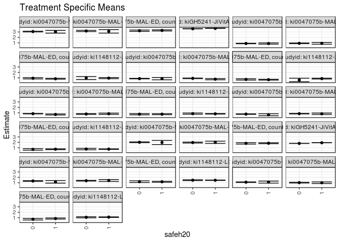

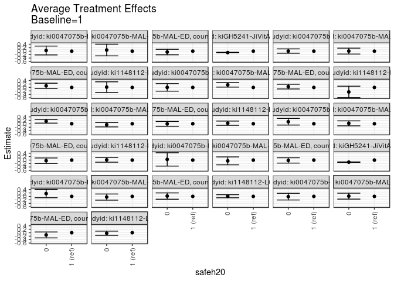

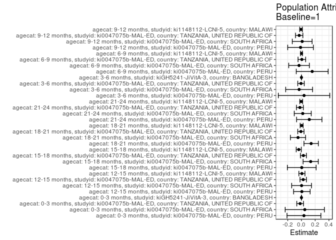

## Results Table

### Parameter: TSM

| agecat | studyid | country | intervention_level | baseline_level | estimate | ci_lower | ci_upper |
| --- | --- | --- | --- | --- | --- | --- | --- |
| 0-3 months | ki0047075b-MAL-ED | PERU | 1 | NA | 3.0405135 | 2.7936384 | 3.2873886 |
| 0-3 months | ki0047075b-MAL-ED | PERU | 0 | NA | 3.0779674 | 3.0085564 | 3.1473784 |
| 0-3 months | ki0047075b-MAL-ED | SOUTH AFRICA | 1 | NA | 3.1186211 | 2.7977355 | 3.4395067 |
| 0-3 months | ki0047075b-MAL-ED | SOUTH AFRICA | 0 | NA | 3.1837583 | 3.0782360 | 3.2892806 |
| 0-3 months | ki0047075b-MAL-ED | TANZANIA, UNITED REPUBLIC OF | 1 | NA | 3.2825556 | 3.1839120 | 3.3811993 |
| 0-3 months | ki0047075b-MAL-ED | TANZANIA, UNITED REPUBLIC OF | 0 | NA | 3.2318280 | 3.1065005 | 3.3571554 |
| 0-3 months | kiGH5241-JiVitA-3 | BANGLADESH | 1 | NA | 3.6647026 | 3.6542072 | 3.6751980 |
| 0-3 months | kiGH5241-JiVitA-3 | BANGLADESH | 0 | NA | 3.5828403 | 3.5727382 | 3.5929424 |
| 3-6 months | ki0047075b-MAL-ED | PERU | 1 | NA | 1.9735918 | 1.5932823 | 2.3539014 |
| 3-6 months | ki0047075b-MAL-ED | PERU | 0 | NA | 2.0129535 | 1.9429719 | 2.0829350 |
| 3-6 months | ki0047075b-MAL-ED | SOUTH AFRICA | 1 | NA | 2.0074932 | 1.7957533 | 2.2192330 |
| 3-6 months | ki0047075b-MAL-ED | SOUTH AFRICA | 0 | NA | 1.9615859 | 1.8736354 | 2.0495364 |
| 3-6 months | ki0047075b-MAL-ED | TANZANIA, UNITED REPUBLIC OF | 1 | NA | 1.8352926 | 1.7538682 | 1.9167170 |
| 3-6 months | ki0047075b-MAL-ED | TANZANIA, UNITED REPUBLIC OF | 0 | NA | 1.8160052 | 1.6862802 | 1.9457301 |
| 3-6 months | kiGH5241-JiVitA-3 | BANGLADESH | 1 | NA | 1.9203154 | 1.9096054 | 1.9310254 |
| 3-6 months | kiGH5241-JiVitA-3 | BANGLADESH | 0 | NA | 1.8011938 | 1.7911233 | 1.8112642 |
| 6-9 months | ki0047075b-MAL-ED | PERU | 1 | NA | 1.1603298 | 0.9272872 | 1.3933724 |
| 6-9 months | ki0047075b-MAL-ED | PERU | 0 | NA | 1.3236438 | 1.2664759 | 1.3808117 |
| 6-9 months | ki0047075b-MAL-ED | SOUTH AFRICA | 1 | NA | 1.4121554 | 1.2497428 | 1.5745680 |
| 6-9 months | ki0047075b-MAL-ED | SOUTH AFRICA | 0 | NA | 1.3739136 | 1.3030818 | 1.4447453 |
| 6-9 months | ki0047075b-MAL-ED | TANZANIA, UNITED REPUBLIC OF | 1 | NA | 1.1811667 | 1.0910597 | 1.2712738 |
| 6-9 months | ki0047075b-MAL-ED | TANZANIA, UNITED REPUBLIC OF | 0 | NA | 1.2003406 | 1.0428592 | 1.3578220 |
| 6-9 months | ki1148112-LCNI-5 | MALAWI | 1 | NA | 1.4580858 | 1.4167366 | 1.4994351 |
| 6-9 months | ki1148112-LCNI-5 | MALAWI | 0 | NA | 1.4682443 | 1.3887265 | 1.5477622 |
| 9-12 months | ki0047075b-MAL-ED | PERU | 1 | NA | 1.1160877 | 0.9289289 | 1.3032464 |
| 9-12 months | ki0047075b-MAL-ED | PERU | 0 | NA | 1.1019161 | 1.0482767 | 1.1555555 |
| 9-12 months | ki0047075b-MAL-ED | SOUTH AFRICA | 1 | NA | 1.0040218 | 0.8495378 | 1.1585058 |
| 9-12 months | ki0047075b-MAL-ED | SOUTH AFRICA | 0 | NA | 1.0189222 | 0.9465160 | 1.0913285 |
| 9-12 months | ki0047075b-MAL-ED | TANZANIA, UNITED REPUBLIC OF | 1 | NA | 0.8485466 | 0.7477258 | 0.9493673 |
| 9-12 months | ki0047075b-MAL-ED | TANZANIA, UNITED REPUBLIC OF | 0 | NA | 0.7189278 | 0.5792579 | 0.8585977 |
| 9-12 months | ki1148112-LCNI-5 | MALAWI | 1 | NA | 1.1069421 | 1.0537119 | 1.1601723 |
| 9-12 months | ki1148112-LCNI-5 | MALAWI | 0 | NA | 1.0770203 | 0.9712069 | 1.1828337 |
| 12-15 months | ki0047075b-MAL-ED | PERU | 1 | NA | 0.8846595 | 0.7695897 | 0.9997294 |
| 12-15 months | ki0047075b-MAL-ED | PERU | 0 | NA | 0.8907084 | 0.8410984 | 0.9403185 |
| 12-15 months | ki0047075b-MAL-ED | SOUTH AFRICA | 1 | NA | 0.9155003 | 0.7584995 | 1.0725012 |
| 12-15 months | ki0047075b-MAL-ED | SOUTH AFRICA | 0 | NA | 0.9195924 | 0.8566753 | 0.9825095 |
| 12-15 months | ki0047075b-MAL-ED | TANZANIA, UNITED REPUBLIC OF | 1 | NA | 0.8287440 | 0.7480637 | 0.9094243 |
| 12-15 months | ki0047075b-MAL-ED | TANZANIA, UNITED REPUBLIC OF | 0 | NA | 0.9239749 | 0.8017008 | 1.0462490 |
| 12-15 months | ki1148112-LCNI-5 | MALAWI | 1 | NA | 0.9513489 | 0.8408411 | 1.0618568 |
| 12-15 months | ki1148112-LCNI-5 | MALAWI | 0 | NA | 0.9703095 | 0.6971386 | 1.2434805 |
| 15-18 months | ki0047075b-MAL-ED | PERU | 1 | NA | 0.8534728 | 0.6397559 | 1.0671898 |
| 15-18 months | ki0047075b-MAL-ED | PERU | 0 | NA | 0.8578623 | 0.8135834 | 0.9021411 |
| 15-18 months | ki0047075b-MAL-ED | SOUTH AFRICA | 1 | NA | 0.7529469 | 0.6374779 | 0.8684159 |
| 15-18 months | ki0047075b-MAL-ED | SOUTH AFRICA | 0 | NA | 0.9057967 | 0.8472031 | 0.9643903 |
| 15-18 months | ki0047075b-MAL-ED | TANZANIA, UNITED REPUBLIC OF | 1 | NA | 0.6579968 | 0.5842619 | 0.7317317 |
| 15-18 months | ki0047075b-MAL-ED | TANZANIA, UNITED REPUBLIC OF | 0 | NA | 0.7078835 | 0.5939858 | 0.8217812 |
| 15-18 months | ki1148112-LCNI-5 | MALAWI | 1 | NA | 0.8623055 | 0.7889850 | 0.9356261 |
| 15-18 months | ki1148112-LCNI-5 | MALAWI | 0 | NA | 0.6030703 | 0.2786579 | 0.9274827 |
| 18-21 months | ki0047075b-MAL-ED | PERU | 1 | NA | 0.6966493 | 0.5976815 | 0.7956172 |
| 18-21 months | ki0047075b-MAL-ED | PERU | 0 | NA | 0.8438128 | 0.7975106 | 0.8901149 |
| 18-21 months | ki0047075b-MAL-ED | SOUTH AFRICA | 1 | NA | 0.8312213 | 0.7194256 | 0.9430171 |
| 18-21 months | ki0047075b-MAL-ED | SOUTH AFRICA | 0 | NA | 0.7788667 | 0.7157945 | 0.8419389 |
| 18-21 months | ki0047075b-MAL-ED | TANZANIA, UNITED REPUBLIC OF | 1 | NA | 0.7498517 | 0.6626134 | 0.8370899 |
| 18-21 months | ki0047075b-MAL-ED | TANZANIA, UNITED REPUBLIC OF | 0 | NA | 0.7456381 | 0.6387634 | 0.8525129 |
| 18-21 months | ki1148112-LCNI-5 | MALAWI | 1 | NA | 0.8169688 | 0.7654775 | 0.8684602 |
| 18-21 months | ki1148112-LCNI-5 | MALAWI | 0 | NA | 0.8510725 | 0.7407633 | 0.9613818 |
| 21-24 months | ki0047075b-MAL-ED | PERU | 1 | NA | 0.6442119 | 0.4583975 | 0.8300263 |
| 21-24 months | ki0047075b-MAL-ED | PERU | 0 | NA | 0.7627749 | 0.7144494 | 0.8111003 |
| 21-24 months | ki0047075b-MAL-ED | SOUTH AFRICA | 1 | NA | 0.8208162 | 0.6886225 | 0.9530100 |
| 21-24 months | ki0047075b-MAL-ED | SOUTH AFRICA | 0 | NA | 0.8443667 | 0.7880158 | 0.9007176 |
| 21-24 months | ki0047075b-MAL-ED | TANZANIA, UNITED REPUBLIC OF | 1 | NA | 0.7402840 | 0.6705911 | 0.8099768 |
| 21-24 months | ki0047075b-MAL-ED | TANZANIA, UNITED REPUBLIC OF | 0 | NA | 0.7052764 | 0.5637091 | 0.8468436 |
| 21-24 months | ki1148112-LCNI-5 | MALAWI | 1 | NA | 0.7538765 | 0.7046621 | 0.8030910 |
| 21-24 months | ki1148112-LCNI-5 | MALAWI | 0 | NA | 0.7668358 | 0.6427673 | 0.8909044 |

### Parameter: E(Y)

| agecat | studyid | country | intervention_level | baseline_level | estimate | ci_lower | ci_upper |
| --- | --- | --- | --- | --- | --- | --- | --- |
| 0-3 months | ki0047075b-MAL-ED | PERU | NA | NA | 3.0766479 | 3.0096811 | 3.1436148 |
| 0-3 months | ki0047075b-MAL-ED | SOUTH AFRICA | NA | NA | 3.1670516 | 3.0651964 | 3.2689068 |
| 0-3 months | ki0047075b-MAL-ED | TANZANIA, UNITED REPUBLIC OF | NA | NA | 3.2631757 | 3.1854001 | 3.3409512 |
| 0-3 months | kiGH5241-JiVitA-3 | BANGLADESH | NA | NA | 3.6645502 | 3.6543148 | 3.6747857 |
| 3-6 months | ki0047075b-MAL-ED | PERU | NA | NA | 2.0114190 | 1.9435740 | 2.0792639 |
| 3-6 months | ki0047075b-MAL-ED | SOUTH AFRICA | NA | NA | 1.9735408 | 1.8927925 | 2.0542892 |
| 3-6 months | ki0047075b-MAL-ED | TANZANIA, UNITED REPUBLIC OF | NA | NA | 1.8286113 | 1.7605412 | 1.8966813 |
| 3-6 months | kiGH5241-JiVitA-3 | BANGLADESH | NA | NA | 1.9201969 | 1.9097350 | 1.9306589 |
| 6-9 months | ki0047075b-MAL-ED | PERU | NA | NA | 1.3168407 | 1.2615074 | 1.3721740 |
| 6-9 months | ki0047075b-MAL-ED | SOUTH AFRICA | NA | NA | 1.3769400 | 1.3125507 | 1.4413293 |
| 6-9 months | ki0047075b-MAL-ED | TANZANIA, UNITED REPUBLIC OF | NA | NA | 1.1868199 | 1.1090396 | 1.2646002 |
| 6-9 months | ki1148112-LCNI-5 | MALAWI | NA | NA | 1.4589363 | 1.4224162 | 1.4954563 |
| 9-12 months | ki0047075b-MAL-ED | PERU | NA | NA | 1.1024805 | 1.0504394 | 1.1545215 |
| 9-12 months | ki0047075b-MAL-ED | SOUTH AFRICA | NA | NA | 1.0146639 | 0.9495597 | 1.0797680 |
| 9-12 months | ki0047075b-MAL-ED | TANZANIA, UNITED REPUBLIC OF | NA | NA | 0.8155931 | 0.7342357 | 0.8969504 |
| 9-12 months | ki1148112-LCNI-5 | MALAWI | NA | NA | 1.1007887 | 1.0539615 | 1.1476158 |
| 12-15 months | ki0047075b-MAL-ED | PERU | NA | NA | 0.8904833 | 0.8425275 | 0.9384392 |
| 12-15 months | ki0047075b-MAL-ED | SOUTH AFRICA | NA | NA | 0.9172722 | 0.8595621 | 0.9749824 |
| 12-15 months | ki0047075b-MAL-ED | TANZANIA, UNITED REPUBLIC OF | NA | NA | 0.8542196 | 0.7897390 | 0.9187003 |
| 12-15 months | ki1148112-LCNI-5 | MALAWI | NA | NA | 0.9578403 | 0.8612449 | 1.0544357 |
| 15-18 months | ki0047075b-MAL-ED | PERU | NA | NA | 0.8576910 | 0.8143303 | 0.9010517 |
| 15-18 months | ki0047075b-MAL-ED | SOUTH AFRICA | NA | NA | 0.8873549 | 0.8344616 | 0.9402481 |
| 15-18 months | ki0047075b-MAL-ED | TANZANIA, UNITED REPUBLIC OF | NA | NA | 0.6862933 | 0.6249762 | 0.7476104 |
| 15-18 months | ki1148112-LCNI-5 | MALAWI | NA | NA | 0.8227868 | 0.7513696 | 0.8942040 |
| 18-21 months | ki0047075b-MAL-ED | PERU | NA | NA | 0.8378061 | 0.7930237 | 0.8825886 |
| 18-21 months | ki0047075b-MAL-ED | SOUTH AFRICA | NA | NA | 0.7810829 | 0.7253333 | 0.8368325 |
| 18-21 months | ki0047075b-MAL-ED | TANZANIA, UNITED REPUBLIC OF | NA | NA | 0.7413740 | 0.6736807 | 0.8090672 |
| 18-21 months | ki1148112-LCNI-5 | MALAWI | NA | NA | 0.8198090 | 0.7732927 | 0.8663254 |
| 21-24 months | ki0047075b-MAL-ED | PERU | NA | NA | 0.7582148 | 0.7110844 | 0.8053451 |
| 21-24 months | ki0047075b-MAL-ED | SOUTH AFRICA | NA | NA | 0.8395115 | 0.7878135 | 0.8912095 |
| 21-24 months | ki0047075b-MAL-ED | TANZANIA, UNITED REPUBLIC OF | NA | NA | 0.7174798 | 0.6527204 | 0.7822392 |
| 21-24 months | ki1148112-LCNI-5 | MALAWI | NA | NA | 0.7505036 | 0.7048983 | 0.7961088 |

### Parameter: ATE

| agecat | studyid | country | intervention_level | baseline_level | estimate | ci_lower | ci_upper |
| --- | --- | --- | --- | --- | --- | --- | --- |
| 0-3 months | ki0047075b-MAL-ED | PERU | 1 | 1 | 0.0000000 | 0.0000000 | 0.0000000 |
| 0-3 months | ki0047075b-MAL-ED | PERU | 0 | 1 | 0.0374539 | -0.2190827 | 0.2939905 |
| 0-3 months | ki0047075b-MAL-ED | SOUTH AFRICA | 1 | 1 | 0.0000000 | 0.0000000 | 0.0000000 |
| 0-3 months | ki0047075b-MAL-ED | SOUTH AFRICA | 0 | 1 | 0.0651372 | -0.2728710 | 0.4031454 |
| 0-3 months | ki0047075b-MAL-ED | TANZANIA, UNITED REPUBLIC OF | 1 | 1 | 0.0000000 | 0.0000000 | 0.0000000 |
| 0-3 months | ki0047075b-MAL-ED | TANZANIA, UNITED REPUBLIC OF | 0 | 1 | -0.0507277 | -0.2108284 | 0.1093731 |
| 0-3 months | kiGH5241-JiVitA-3 | BANGLADESH | 1 | 1 | 0.0000000 | 0.0000000 | 0.0000000 |
| 0-3 months | kiGH5241-JiVitA-3 | BANGLADESH | 0 | 1 | -0.0818623 | -0.0963003 | -0.0674243 |
| 3-6 months | ki0047075b-MAL-ED | PERU | 1 | 1 | 0.0000000 | 0.0000000 | 0.0000000 |
| 3-6 months | ki0047075b-MAL-ED | PERU | 0 | 1 | 0.0393616 | -0.3474423 | 0.4261655 |
| 3-6 months | ki0047075b-MAL-ED | SOUTH AFRICA | 1 | 1 | 0.0000000 | 0.0000000 | 0.0000000 |
| 3-6 months | ki0047075b-MAL-ED | SOUTH AFRICA | 0 | 1 | -0.0459072 | -0.2753431 | 0.1835286 |
| 3-6 months | ki0047075b-MAL-ED | TANZANIA, UNITED REPUBLIC OF | 1 | 1 | 0.0000000 | 0.0000000 | 0.0000000 |
| 3-6 months | ki0047075b-MAL-ED | TANZANIA, UNITED REPUBLIC OF | 0 | 1 | -0.0192874 | -0.1726696 | 0.1340947 |
| 3-6 months | kiGH5241-JiVitA-3 | BANGLADESH | 1 | 1 | 0.0000000 | 0.0000000 | 0.0000000 |
| 3-6 months | kiGH5241-JiVitA-3 | BANGLADESH | 0 | 1 | -0.1191216 | -0.1332165 | -0.1050268 |
| 6-9 months | ki0047075b-MAL-ED | PERU | 1 | 1 | 0.0000000 | 0.0000000 | 0.0000000 |
| 6-9 months | ki0047075b-MAL-ED | PERU | 0 | 1 | 0.1633140 | -0.0771030 | 0.4037309 |
| 6-9 months | ki0047075b-MAL-ED | SOUTH AFRICA | 1 | 1 | 0.0000000 | 0.0000000 | 0.0000000 |
| 6-9 months | ki0047075b-MAL-ED | SOUTH AFRICA | 0 | 1 | -0.0382419 | -0.2163832 | 0.1398994 |
| 6-9 months | ki0047075b-MAL-ED | TANZANIA, UNITED REPUBLIC OF | 1 | 1 | 0.0000000 | 0.0000000 | 0.0000000 |
| 6-9 months | ki0047075b-MAL-ED | TANZANIA, UNITED REPUBLIC OF | 0 | 1 | 0.0191738 | -0.1630430 | 0.2013907 |
| 6-9 months | ki1148112-LCNI-5 | MALAWI | 1 | 1 | 0.0000000 | 0.0000000 | 0.0000000 |
| 6-9 months | ki1148112-LCNI-5 | MALAWI | 0 | 1 | 0.0101585 | -0.0797972 | 0.1001142 |
| 9-12 months | ki0047075b-MAL-ED | PERU | 1 | 1 | 0.0000000 | 0.0000000 | 0.0000000 |
| 9-12 months | ki0047075b-MAL-ED | PERU | 0 | 1 | -0.0141716 | -0.2088651 | 0.1805220 |
| 9-12 months | ki0047075b-MAL-ED | SOUTH AFRICA | 1 | 1 | 0.0000000 | 0.0000000 | 0.0000000 |
| 9-12 months | ki0047075b-MAL-ED | SOUTH AFRICA | 0 | 1 | 0.0149004 | -0.1563960 | 0.1861969 |
| 9-12 months | ki0047075b-MAL-ED | TANZANIA, UNITED REPUBLIC OF | 1 | 1 | 0.0000000 | 0.0000000 | 0.0000000 |
| 9-12 months | ki0047075b-MAL-ED | TANZANIA, UNITED REPUBLIC OF | 0 | 1 | -0.1296188 | -0.3019706 | 0.0427331 |
| 9-12 months | ki1148112-LCNI-5 | MALAWI | 1 | 1 | 0.0000000 | 0.0000000 | 0.0000000 |
| 9-12 months | ki1148112-LCNI-5 | MALAWI | 0 | 1 | -0.0299218 | -0.1498601 | 0.0900165 |
| 12-15 months | ki0047075b-MAL-ED | PERU | 1 | 1 | 0.0000000 | 0.0000000 | 0.0000000 |
| 12-15 months | ki0047075b-MAL-ED | PERU | 0 | 1 | 0.0060489 | -0.1192597 | 0.1313574 |
| 12-15 months | ki0047075b-MAL-ED | SOUTH AFRICA | 1 | 1 | 0.0000000 | 0.0000000 | 0.0000000 |
| 12-15 months | ki0047075b-MAL-ED | SOUTH AFRICA | 0 | 1 | 0.0040920 | -0.1663783 | 0.1745624 |
| 12-15 months | ki0047075b-MAL-ED | TANZANIA, UNITED REPUBLIC OF | 1 | 1 | 0.0000000 | 0.0000000 | 0.0000000 |
| 12-15 months | ki0047075b-MAL-ED | TANZANIA, UNITED REPUBLIC OF | 0 | 1 | 0.0952309 | -0.0559021 | 0.2463640 |
| 12-15 months | ki1148112-LCNI-5 | MALAWI | 1 | 1 | 0.0000000 | 0.0000000 | 0.0000000 |
| 12-15 months | ki1148112-LCNI-5 | MALAWI | 0 | 1 | 0.0189606 | -0.2892227 | 0.3271439 |
| 15-18 months | ki0047075b-MAL-ED | PERU | 1 | 1 | 0.0000000 | 0.0000000 | 0.0000000 |
| 15-18 months | ki0047075b-MAL-ED | PERU | 0 | 1 | 0.0043894 | -0.2138663 | 0.2226452 |
| 15-18 months | ki0047075b-MAL-ED | SOUTH AFRICA | 1 | 1 | 0.0000000 | 0.0000000 | 0.0000000 |
| 15-18 months | ki0047075b-MAL-ED | SOUTH AFRICA | 0 | 1 | 0.1528498 | 0.0231235 | 0.2825762 |
| 15-18 months | ki0047075b-MAL-ED | TANZANIA, UNITED REPUBLIC OF | 1 | 1 | 0.0000000 | 0.0000000 | 0.0000000 |
| 15-18 months | ki0047075b-MAL-ED | TANZANIA, UNITED REPUBLIC OF | 0 | 1 | 0.0498867 | -0.0871828 | 0.1869563 |
| 15-18 months | ki1148112-LCNI-5 | MALAWI | 1 | 1 | 0.0000000 | 0.0000000 | 0.0000000 |
| 15-18 months | ki1148112-LCNI-5 | MALAWI | 0 | 1 | -0.2592353 | -0.5920509 | 0.0735804 |
| 18-21 months | ki0047075b-MAL-ED | PERU | 1 | 1 | 0.0000000 | 0.0000000 | 0.0000000 |
| 18-21 months | ki0047075b-MAL-ED | PERU | 0 | 1 | 0.1471634 | 0.0378999 | 0.2564270 |
| 18-21 months | ki0047075b-MAL-ED | SOUTH AFRICA | 1 | 1 | 0.0000000 | 0.0000000 | 0.0000000 |
| 18-21 months | ki0047075b-MAL-ED | SOUTH AFRICA | 0 | 1 | -0.0523546 | -0.1813562 | 0.0766469 |
| 18-21 months | ki0047075b-MAL-ED | TANZANIA, UNITED REPUBLIC OF | 1 | 1 | 0.0000000 | 0.0000000 | 0.0000000 |
| 18-21 months | ki0047075b-MAL-ED | TANZANIA, UNITED REPUBLIC OF | 0 | 1 | -0.0042135 | -0.1434622 | 0.1350351 |
| 18-21 months | ki1148112-LCNI-5 | MALAWI | 1 | 1 | 0.0000000 | 0.0000000 | 0.0000000 |
| 18-21 months | ki1148112-LCNI-5 | MALAWI | 0 | 1 | 0.0341037 | -0.0880895 | 0.1562968 |
| 21-24 months | ki0047075b-MAL-ED | PERU | 1 | 1 | 0.0000000 | 0.0000000 | 0.0000000 |
| 21-24 months | ki0047075b-MAL-ED | PERU | 0 | 1 | 0.1185629 | -0.0734327 | 0.3105586 |
| 21-24 months | ki0047075b-MAL-ED | SOUTH AFRICA | 1 | 1 | 0.0000000 | 0.0000000 | 0.0000000 |
| 21-24 months | ki0047075b-MAL-ED | SOUTH AFRICA | 0 | 1 | 0.0235505 | -0.1203710 | 0.1674719 |
| 21-24 months | ki0047075b-MAL-ED | TANZANIA, UNITED REPUBLIC OF | 1 | 1 | 0.0000000 | 0.0000000 | 0.0000000 |
| 21-24 months | ki0047075b-MAL-ED | TANZANIA, UNITED REPUBLIC OF | 0 | 1 | -0.0350076 | -0.1931908 | 0.1231756 |
| 21-24 months | ki1148112-LCNI-5 | MALAWI | 1 | 1 | 0.0000000 | 0.0000000 | 0.0000000 |
| 21-24 months | ki1148112-LCNI-5 | MALAWI | 0 | 1 | 0.0129593 | -0.1215412 | 0.1474598 |

### Parameter: PAR

| agecat | studyid | country | intervention_level | baseline_level | estimate | ci_lower | ci_upper |
| --- | --- | --- | --- | --- | --- | --- | --- |
| 0-3 months | ki0047075b-MAL-ED | PERU | 1 | NA | 0.0361345 | -0.2108195 | 0.2830884 |
| 0-3 months | ki0047075b-MAL-ED | SOUTH AFRICA | 1 | NA | 0.0484305 | -0.2372698 | 0.3341308 |
| 0-3 months | ki0047075b-MAL-ED | TANZANIA, UNITED REPUBLIC OF | 1 | NA | -0.0193800 | -0.0683708 | 0.0296108 |
| 0-3 months | kiGH5241-JiVitA-3 | BANGLADESH | 1 | NA | -0.0001524 | -0.0005122 | 0.0002074 |
| 3-6 months | ki0047075b-MAL-ED | PERU | 1 | NA | 0.0378271 | -0.3370339 | 0.4126881 |
| 3-6 months | ki0047075b-MAL-ED | SOUTH AFRICA | 1 | NA | -0.0339523 | -0.2297828 | 0.1618781 |
| 3-6 months | ki0047075b-MAL-ED | TANZANIA, UNITED REPUBLIC OF | 1 | NA | -0.0066813 | -0.0540021 | 0.0406395 |
| 3-6 months | kiGH5241-JiVitA-3 | BANGLADESH | 1 | NA | -0.0001185 | -0.0004741 | 0.0002372 |
| 6-9 months | ki0047075b-MAL-ED | PERU | 1 | NA | 0.1565109 | -0.0759671 | 0.3889889 |
| 6-9 months | ki0047075b-MAL-ED | SOUTH AFRICA | 1 | NA | -0.0352154 | -0.1857590 | 0.1153282 |
| 6-9 months | ki0047075b-MAL-ED | TANZANIA, UNITED REPUBLIC OF | 1 | NA | 0.0056532 | -0.0499930 | 0.0612994 |
| 6-9 months | ki1148112-LCNI-5 | MALAWI | 1 | NA | 0.0008504 | -0.0136935 | 0.0153943 |
| 9-12 months | ki0047075b-MAL-ED | PERU | 1 | NA | -0.0136072 | -0.2005478 | 0.1733334 |
| 9-12 months | ki0047075b-MAL-ED | SOUTH AFRICA | 1 | NA | 0.0106421 | -0.1337613 | 0.1550455 |
| 9-12 months | ki0047075b-MAL-ED | TANZANIA, UNITED REPUBLIC OF | 1 | NA | -0.0329535 | -0.0862529 | 0.0203459 |
| 9-12 months | ki1148112-LCNI-5 | MALAWI | 1 | NA | -0.0061534 | -0.0255557 | 0.0132488 |
| 12-15 months | ki0047075b-MAL-ED | PERU | 1 | NA | 0.0058238 | -0.1148222 | 0.1264698 |
| 12-15 months | ki0047075b-MAL-ED | SOUTH AFRICA | 1 | NA | 0.0017719 | -0.1425638 | 0.1461076 |
| 12-15 months | ki0047075b-MAL-ED | TANZANIA, UNITED REPUBLIC OF | 1 | NA | 0.0254756 | -0.0210214 | 0.0719727 |
| 12-15 months | ki1148112-LCNI-5 | MALAWI | 1 | NA | 0.0064914 | -0.0379476 | 0.0509304 |
| 15-18 months | ki0047075b-MAL-ED | PERU | 1 | NA | 0.0042181 | -0.2055203 | 0.2139566 |
| 15-18 months | ki0047075b-MAL-ED | SOUTH AFRICA | 1 | NA | 0.1344080 | 0.0237847 | 0.2450312 |
| 15-18 months | ki0047075b-MAL-ED | TANZANIA, UNITED REPUBLIC OF | 1 | NA | 0.0282965 | -0.0153074 | 0.0719005 |
| 15-18 months | ki1148112-LCNI-5 | MALAWI | 1 | NA | -0.0395188 | -0.0764461 | -0.0025915 |
| 18-21 months | ki0047075b-MAL-ED | PERU | 1 | NA | 0.1411568 | 0.0362733 | 0.2460402 |
| 18-21 months | ki0047075b-MAL-ED | SOUTH AFRICA | 1 | NA | -0.0501384 | -0.1605226 | 0.0602458 |
| 18-21 months | ki0047075b-MAL-ED | TANZANIA, UNITED REPUBLIC OF | 1 | NA | -0.0084777 | -0.0541951 | 0.0372396 |
| 18-21 months | ki1148112-LCNI-5 | MALAWI | 1 | NA | 0.0028402 | -0.0186994 | 0.0243798 |
| 21-24 months | ki0047075b-MAL-ED | PERU | 1 | NA | 0.1140028 | -0.0706383 | 0.2986439 |
| 21-24 months | ki0047075b-MAL-ED | SOUTH AFRICA | 1 | NA | 0.0186953 | -0.1051349 | 0.1425255 |
| 21-24 months | ki0047075b-MAL-ED | TANZANIA, UNITED REPUBLIC OF | 1 | NA | -0.0228042 | -0.0730476 | 0.0274392 |
| 21-24 months | ki1148112-LCNI-5 | MALAWI | 1 | NA | -0.0033730 | -0.0243519 | 0.0176060 |